# ETC3250/5250 Tutorial 8 Solution

Neural networks

prepared by Professor Di Cook

Week 8

## ⚙️ Exercises

This exercise is investigating neural network model fitting. A neural network model was fitted to the `wiggle.csv` using the `nnet` package in R, from many random starts, and using 2-4 nodes in the hidden layer. The best model is in the data object `nnet_best.rda`, and the full set of model fits are stored in `nnet_many.rda`. We are going investigate the best fit, and the complete set of fits. The data set is actually a test set, it was not used to fit the model, but it was simulated from the same process as the training set, which we don’t have.

### 1.

Read in the data, and make an appropriate plot, that communicates the relationship between the two variables and the two groups.

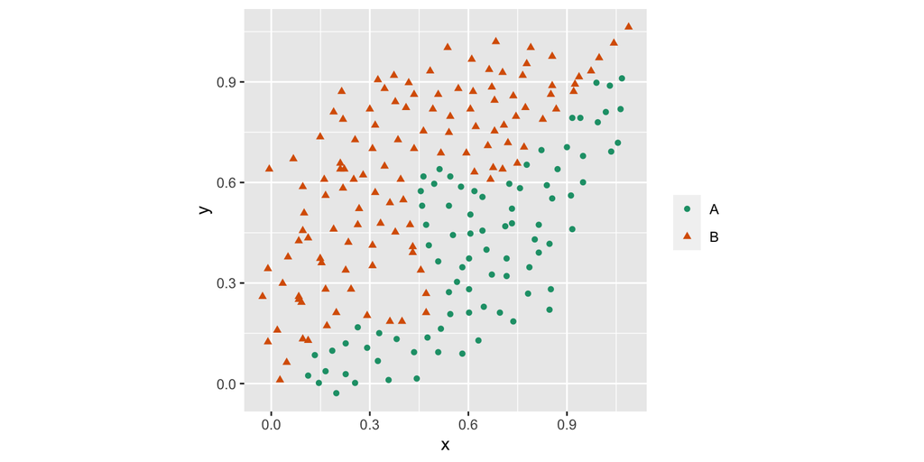

```r
library(tidyverse)
library(nnet)

w <- read_csv(here::here("data/wiggly.csv"))
ggplot(w, aes(x=x, y=y, colour=class, shape=class)) +
  geom_point() +
  scale_color_brewer("", palette="Dark2") +
  scale_shape("") +
  theme(aspect.ratio=1)
```

### 2.

Read in the best model. Take a look at the object. There are three components: `hidden`, `output` and `nnet`. The best model uses $s=4$. The `nnet` component has the estimated model coefficients, fitted values and residuals. The `hidden` component has information related to the models used in the 4 nodes of the hidden layer, and the `output` has the same information for the second layer. These latter two contain a grid of values for the predictors, $x$, $y$ and the predicted values for each grid point.

#### a.

Plot the grid of predicted values for the second layer, using node 1. Overlay the data. How well has the model captured the class structure?

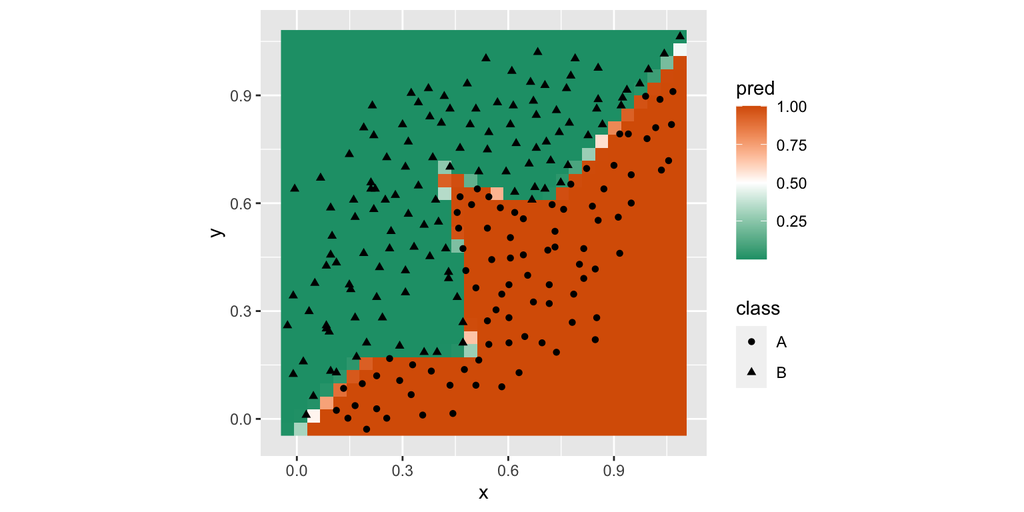

```r
load(here::here("data/nnet_many.rda"))
load(here::here("data/nnet_best.rda"))

ggplot(subset(best$output,  node == 1), aes(x, y)) +
  geom_raster(aes(fill = pred)) +
  geom_point(aes(shape = class), data = w) +
  scale_fill_gradient2(low="#1B9E77", high="#D95F02", mid = "white", midpoint = 0.5) +
  theme(aspect.ratio=1)
```

**The model does amazingly well to predict this data.**

#### b.

Plot the grid of predicted values for each node in the hidden layer, with the data overlaid. Explain how the models at each node would combine to make the final model predictions, which we have already seen are extremely good.

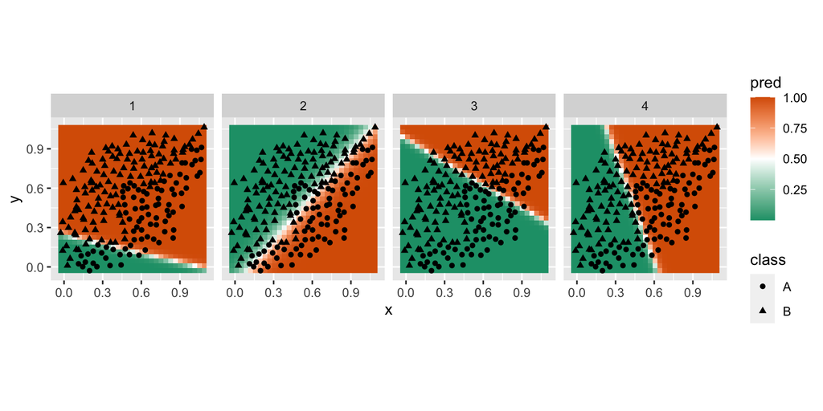

```r
ggplot(best$hidden, aes(x, y)) +
  geom_raster(aes(fill = pred)) +
  geom_point(aes(shape = class), data = w) +
  scale_fill_gradient2(low="#1B9E77", high="#D95F02", mid = "white", midpoint = 0.5) +
  facet_grid(. ~ node) +
  theme(aspect.ratio=1)
```

**We can see that each captures one linear aspect, of the nonlinear boundary.**

#### c.

How many parameters are there in this model? Check that your answer matches the number of values in the `wgts` element of the `nnet` component.

**p=2, s=4, so there are 3x4=12. s=4 and there are two levels of output, so 5x2=10. There are 22 parameters.**

#### d.

Write down the equation corresponding to the model at first node of the hidden layer. You need to look at the `wgts` element of the `nnet` component. There are 6 sets of linear model coefficients.

**The coefficients are:**

```r
best[[3]]$wts[1:3]
# [1] -19.01764  18.21640  77.10483
```

#### e.

ADVANCED: See if you can compute the combination of the prediction on each hidden node, to get final prediction.

### 3.

Read in the complete set of models fitted. There were 600 models fitted, 200 random starts for each $s = 2, 3, 4$. The `nnet` function has its own measure of the goodness of fit, which is used to determine when to stop minimising RSS, which is called `value` in this data. (You can think of this like it is training error.) Plot the predictive accuracy against function’s returned value of model fit. Explain how the change in $s$ affects the predictive accuracy.

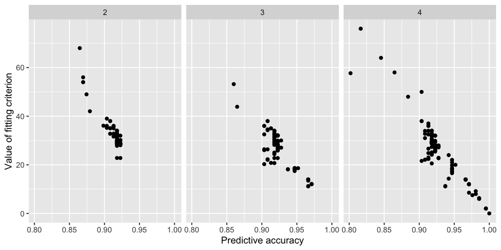

```r
qual <- many %>% dplyr::select(value, accuracy, nodes, id) %>%
  distinct()
ggplot(data = qual, aes(accuracy, value)) +
  geom_point() +
  xlab("Predictive accuracy") + ylab("Value of fitting criterion") +
  facet_wrap(. ~ nodes)
```

**The best performance is achieved by the 4 node models. The predictive accuracy matches fairly closely the fitting criteria. The biggest feature to note, though, is that there is a lot of variability across models. A different random start can generate a very poor model. It takes some work to find the bext model. But it can be a very good model.**

### 4.

Your turn, use the `nnet` function to fit the wiggly data yourself. Split the wiggly data into training and test sets.

Set a seed, and choose $s=4$. Record the RSS (`value`), and the accuracy for the test set.

Where does your fit lie in terms of all the models Hadley fitted to the data?

Run it again (without re-setting the seed). Is it a different model?

```r
set.seed(2022)
library(rsample)
library(yardstick)
w <- w %>% mutate(class = factor(class))
split <- initial_split(w, 2/3)
w_tr <- training(split)
w_ts <- testing(split)
m1 <- nnet(class~., data = w_tr, size = 4,
           decay = 5e-4, maxit = 500)
# # weights:  17
# initial  value 103.014076
# iter  10 value 29.868560
# iter  20 value 26.658268
# iter  30 value 21.116727
# iter  40 value 19.503874
# iter  50 value 18.347056
# iter  60 value 17.928092
# iter  70 value 17.657727
# iter  80 value 17.606069
# iter  90 value 17.568132
# iter 100 value 17.535956
# iter 110 value 17.526655
# iter 120 value 17.524347
# iter 130 value 17.520285
# iter 140 value 17.510121
# iter 150 value 17.508603
# iter 160 value 17.503119
# iter 170 value 17.501872
# iter 180 value 17.500209
# iter 190 value 17.499107
# iter 200 value 17.497713
# iter 210 value 17.495389
# iter 220 value 17.491515
# iter 230 value 17.486771
# iter 240 value 17.484873
# iter 250 value 17.483568
# iter 260 value 17.483270
# iter 270 value 17.482071
# iter 280 value 17.480298
# iter 290 value 17.479756
# iter 300 value 17.479606
# iter 310 value 17.479495
# final  value 17.479452
# converged
w_ts <- w_ts %>%
  mutate(cl_p1_num = predict(m1, w_ts)) %>%
  mutate(cl_p1 = factor(ifelse(cl_p1_num < 0.5, "A", "B")))
conf_mat(w_ts, truth = class, estimate = cl_p1)
#           Truth
# Prediction  A  B
#          A 21  3
#          B 10 35
```

##### © Copyright 2022 Monash University